# Processing Files and Strings

Often when you're working with data, you have it stored in files. These may be text files, images, audio, code! Just about anything you can imagine!

As a case in point, suppose that a local dentist has a small database of clients stored in a text file. For simplicity, suppose they only keep each clients' first and last name along with their age and phone number. A typical entry looks something like:

```
Manny Hernandez 31 217-321-1234
```

Suppose that the dentist has quite a few clients and wants to get a sense of what the age distribution of his clients is in order to determine if it's worth making special offers to say youth or elderly clients.

How could we start to do something like this?

First, we'd need to read the input and represent it in a useful way. Suppose that we've called the data file 'clients.txt'. Let's go ahead and open it and read the data into Python.

```python
f = open('clients.txt')
data = f.read()
f.close()
data
```

```
'Michelle       Knauss         21  217-326-2757\nStella         Do             39  217-202-3672\nLoree          Whetstone      56  217-364-3180\nAlecia         Brister        58  217-369-2187\nPaulette       Royce          25  217-277-7354\nAlton          Oneal          20  217-360-7421\nJae        …
```

This is an ok start, but notice that all the entries are read as one big string. There are a couple options here. One way to handle this is by splitting the string as follows:

```python
data.split('\n')
```

```
['Michelle       Knauss         21  217-326-2757',
 'Stella         Do             39  217-202-3672',
 'Loree          Whetstone      56  217-364-3180',
 'Alecia         Brister        58  217-369-2187',
 'Paulette       Royce          25  217-277-7354',
 'Alton          Oneal          20  217-360-7421',
 'Jae            Rosecrans      11  217-229-7251',
 'Staci          Crabill        55  217-395-1576',
 'Antonietta     Olguin         43  217-315-7118',
 'Ricky          Tinch          21  217-204-5472',
 'Tom            Ogletree       25  217-354-9250',
 'Deane          Beegle         60  217-357-5927',
 'Filiberto      Massey         38  217-200-9626',
 'Steve          Hadsell        52  217-221-8413',
 'Shawnee        Bibeau         31  217-203-8649',
 'Tianna         Siddall        52  217-268-5767',
 'Emmanuel       Mefford        10  217-276-1283',
 'Yesenia        Moon           24  217-341-2026',
 'Bryanna        Albano         60  217-393-9458',
 'Rikki          Helle          30  217-262-7414',
 'Yuriko         Norby          20  217-372-8624',
 'Jone           Yelle          26  217-275-5638',
 'Yukiko         Elizondo       13  217-275-1878',
 'Carman         Shoup          36  217-296-2503',
 'Maricruz       Furlong        26  217-392-9723',
 'Susan          Look           27  217-392-6052',
 'Maura          Lemond         43  217-202-4303',
 'Carlos         Beauregard     56  217-333-9292',
 'Eric           Digregorio     21  217-238-8827',
 'Shanelle       Pariseau       32  217-256-2110',
 'Barton         Reams          22  217-227-3143',
 'Megan          Deck           53  217-318-4692',
 'Maurice        Minder         49  217-355-5013',
 'Mariann        Hetzel         46  217-272-4041',
 'Louanne        Ettinger       24  217-245-3958',
 'Frida          Ceasar         14  217-256-6017',
 'Cherilyn       Forkey         24  217-368-9606',
 'Erwin          Boring         47  217-209-1653',
 'Danuta         Cahall         21  217-387-9678',
 'Vinita         Karls          40  217-201-6987',
```

[output cut: 45 more lines]

```
 'Leontine       Zoeller        45  217-202-5340',
 'Hassie         Lush           57  217-312-7202',
 'Sigrid         Grimmer        49  217-227-4144',
 'Rosaria        Hayslip        13  217-271-5984',
 'Lawana         Dion           15  217-382-8019',
 'Ronna          Meneely        17  217-290-2456',
 'Rosario        Iannotti       48  217-329-3522',
 'Teena          Koen           47  217-387-1715',
 'Santos         Morais         11  217-376-8328',
 'Clement        Mangione       10  217-217-4424',
 'Lavinia        Vidrine        27  217-301-8274',
 'Bridgette      Gerke          52  217-314-9239',
 'Oralee         Longstreet     17  217-397-5060',
 'Providencia    Stonecipher    30  217-284-5594',
 'Grisel         Hanway         21  217-247-8875']
```

A different way which bypasses this intermediate step is to use *readlines* instead of *read*.

```python
lines = open('clients.txt').readlines()  # now using short version to quickly get contents out!
lines
```

```
['Michelle       Knauss         21  217-326-2757\n',
 'Stella         Do             39  217-202-3672\n',
 'Loree          Whetstone      56  217-364-3180\n',
 'Alecia         Brister        58  217-369-2187\n',
 'Paulette       Royce          25  217-277-7354\n',
 'Alton          Oneal          20  217-360-7421\n',
 'Jae            Rosecrans      11  217-229-7251\n',
 'Staci          Crabill        55  217-395-1576\n',
 'Antonietta     Olguin         43  217-315-7118\n',
 'Ricky          Tinch          21  217-204-5472\n',
 'Tom            Ogletree       25  217-354-9250\n',
 'Deane          Beegle         60  217-357-5927\n',
 'Filiberto      Massey         38  217-200-9626\n',
 'Steve          Hadsell        52  217-221-8413\n',
 'Shawnee        Bibeau         31  217-203-8649\n',
 'Tianna         Siddall        52  217-268-5767\n',
 'Emmanuel       Mefford        10  217-276-1283\n',
 'Yesenia        Moon           24  217-341-2026\n',
 'Bryanna        Albano         60  217-393-9458\n',
 'Rikki          Helle          30  217-262-7414\n',
 'Yuriko         Norby          20  217-372-8624\n',
 'Jone           Yelle          26  217-275-5638\n',
 'Yukiko         Elizondo       13  217-275-1878\n',
 'Carman         Shoup          36  217-296-2503\n',
 'Maricruz       Furlong        26  217-392-9723\n',
 'Susan          Look           27  217-392-6052\n',
 'Maura          Lemond         43  217-202-4303\n',
 'Carlos         Beauregard     56  217-333-9292\n',
 'Eric           Digregorio     21  217-238-8827\n',
 'Shanelle       Pariseau       32  217-256-2110\n',
 'Barton         Reams          22  217-227-3143\n',
 'Megan          Deck           53  217-318-4692\n',
 'Maurice        Minder         49  217-355-5013\n',
 'Mariann        Hetzel         46  217-272-4041\n',
 'Louanne        Ettinger       24  217-245-3958\n',
 'Frida          Ceasar         14  217-256-6017\n',
 'Cherilyn       Forkey         24  217-368-9606\n',
 'Erwin          Boring         47  217-209-1653\n',
 'Danuta         Cahall         21  217-387-9678\n',
 'Vinita         Karls          40  217-201-6987\n',
```

[output cut: 45 more lines]

```
 'Leontine       Zoeller        45  217-202-5340\n',
 'Hassie         Lush           57  217-312-7202\n',
 'Sigrid         Grimmer        49  217-227-4144\n',
 'Rosaria        Hayslip        13  217-271-5984\n',
 'Lawana         Dion           15  217-382-8019\n',
 'Ronna          Meneely        17  217-290-2456\n',
 'Rosario        Iannotti       48  217-329-3522\n',
 'Teena          Koen           47  217-387-1715\n',
 'Santos         Morais         11  217-376-8328\n',
 'Clement        Mangione       10  217-217-4424\n',
 'Lavinia        Vidrine        27  217-301-8274\n',
 'Bridgette      Gerke          52  217-314-9239\n',
 'Oralee         Longstreet     17  217-397-5060\n',
 'Providencia    Stonecipher    30  217-284-5594\n',
 'Grisel         Hanway         21  217-247-8875']
```

In either case, now we have our data represented as a list of individual entries ready for further processing. We'll use the *split* command to do this. First, let's start by looking at a simple case.

```python
s = "this is a string"
s.split()
```

```
['this', 'is', 'a', 'string']
```

```python
s = "this is a multiline string\nthis is the second line"
s.split()
```

```
['this',
 'is',
 'a',
 'multiline',
 'string',
 'this',
 'is',
 'the',
 'second',
 'line']
```

Split also allows you to specify which character I break the string at. A moment ago, I used the following to break at newline characters.

```python
s.split('\n')
```

```
['this is a multiline string', 'this is the second line']
```

## Exercise 1

Read the lines from 'clients.txt', then convert each line into a tuple of ('first', 'last', age, 'phone number') fields. *In particular, make sure that the age field is converted to an integer type, not a string!*

For example, the line

```
'Stella Do 39 217-325-1432'
```

should become

```
('Stella', 'Do', 39, '217-325-1432')
```

## Aside: Optional Arguments in Common Functions

Suppose we want to sort our clients by age. How would we do this?

By default Python's list sort works on tuples entry-by-entry. Hence, running a sort would sort by first name -> last name -> age.

One possible solution hinted at much earlier is to reorder the tuples and then sort. That's fine - but there's a better way!

Many commonly used functions support optional arguments which make them much more flexible. Let's take a look at how to make *sorted* sort by age.

```python
entries = [
    (1, 5),
    (2, 4),
    (6, 9),
    (3, 7),
]

sorted(entries)
```

```
[(1, 5), (2, 4), (3, 7), (6, 9)]
```

```python
def first(entry):
    return entry[0]

def second(entry):
    return entry[1]

print sorted(entries, key=first)
print sorted(entries, key=second)
```

```
[(1, 5), (2, 4), (3, 7), (6, 9)]
[(2, 4), (1, 5), (3, 7), (6, 9)]
```

We can do this even more compactly and not even give a name to our "chooser" function by using Python's *lambda* notation.

```python
print sorted(entries, key=lambda (f, s): f)
print sorted(entries, key=lambda (f, s): s)
```

```
[(1, 5), (2, 4), (3, 7), (6, 9)]
[(2, 4), (1, 5), (3, 7), (6, 9)]
```

## Exercise 2

1. Write a method which takes the client data and a column number and sorts the entries according to that column.
2. Extend this to support "named" columns. For example, I still want to be able to sort using column 0, 1, 2 or 3 as before, but I should also be able to sort by "first name", "last name", "age" or "phone number" too.

## Formatting and Writing Data

Now that we've done a little processing, let's save our data. It turns out that writing data to a file isn't much harder than reading data. For example:

```python
f = open('somewords.txt', 'w')
f.write('hello\n')
f.write('meow\n')
f.write('surfer\n')
f.close()
```

Now, we just need to do this with our sorted table and we'll be done. The only problem is, we need to format our data into a string to write it. How would we do this? On way would be:

```python
entry = ('John', 'Putnam', 63, '217-321-1542')
print str(entry)
```

```
('John', 'Putnam', 63, '217-321-1542')
```

But that's not quite right... We want to format this so that it's flat. To do this, we'll use Python's *format* function.

```python
print '{0} {1} {2} {3}\n'.format(entry[0], entry[1], entry[2], entry[3])
```

```
John Putnam 63 217-321-1542
```

```python
print '{} {} {} {}\n'.format(entry[0], entry[1], entry[2], entry[3])
```

```
John Putnam 63 217-321-1542
```

Even more compactly, we can ask Python to "fill in" the arguments from a tuple using the star-prefix notation.

```python
print '{} {} {} {}\n'.format(*entry)
```

```
John Putnam 63 217-321-1542
```

*Although you can always work around this, the star notation is good to be aware of. It works anytime you want expand a tuple into arguments of a function!*

We won't go in-depth with string formatting here, but the *format* function has a rich array of ways it can format strings. Take a look the range of examples if you're interested!

## Exercise 3

Complete our database processing by writing the table sorted by age to 'people.age.txt'.

# Data Analysis: First Steps Towards the Scipy Stack

Now, we've done some good work in terms of structuring the client data. But, what if we wanted to do some more analysis on it?

For example, we may want a histogram of the clients' ages or a description of the mean and standard deviation of the clients' ages.

Further, we don't just want a list of numbers but some kind of a visual representation of the dataset.

We'll start to address these problems using some basic functionality from two *very* powerful Python modules: Scipy and Matplotlib.

Let's start out with visualizing our data, since pictures are fun to make.

I'll go ahead and process the client data again, but this time only extracting their ages.

```python
def parse(line):
    first, last, age, phone = line.split()
    return int(age)

ages = [parse(line) for line in open('clients.txt')]
```

Now, let's see how to create a basic histogram - nothing fancy.

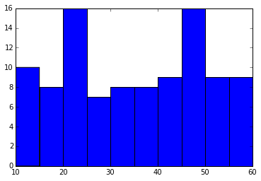

```python
%matplotlib inline
import matplotlib.pyplot as plt

plt.figure()
plt.hist(ages)
plt.show()
```

Now, since we created this plot, we understand what we're looking at, but to someone who comes across this randomly, it's not very useful. Let's see if we can add some context to it.

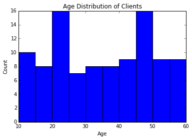

```python
plt.figure()
plt.title('Age Distribution of Clients')
plt.xlabel('Age')
plt.ylabel('Count')
plt.hist(ages)
plt.show()
```

If we're happy with the plot, we can save it for later use using the savefig command instead of show.

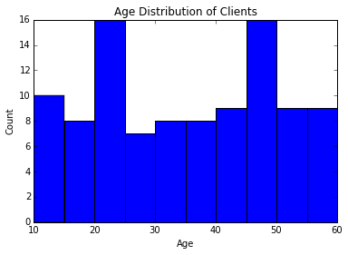

```python
plt.figure()
plt.title('Age Distribution of Clients')
plt.xlabel('Age')
plt.ylabel('Count')
plt.hist(ages)
plt.savefig('age-histogram.png')
```

Now we've gotten some visual feedback of what our distribution looks like. It looks like it has a mean around 35 and a large variance. To quantify this, let's use Scipy's *describe* function.

```python
from scipy.stats import describe
info = describe(ages)
info
```

```
DescribeResult(nobs=100, minmax=(10, 60), mean=34.640000000000001, variance=222.11151515151516, skewness=-0.01047377103097642, kurtosis=-1.28981716368536)
```

Let's try to add this newfound information to our plot!

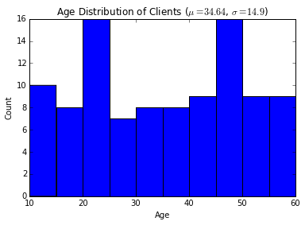

```python
mu = round(info.mean, 2)
sigma = round(info.variance**.5, 2)

plt.figure()
plt.title('Age Distribution of Clients ($\\mu={}$, $\\sigma={}$)'.format(mu, sigma))
plt.xlabel('Age')
plt.ylabel('Count')
plt.hist(ages)
plt.savefig('age-histogram.png')

# The \\ is needed in the title string as \ performs special "escape" commands. For example,
# we've seen that \n produces a newline. \\ just leaves us with a good-ole \
```

Matplotlib is quite flexible in how a plot can be adjusted and tweaked! We could probably spend days discussing these things, but for now, we'll just cover the basics.

## Additional Remarks

A couple question came up during the day. The first was regarding how to format strings to be a certain length. The second was about clarification of the lambda statement.

### More Formatting

In order to format strings to be a certain length or have a certain justification, we can add to the replacement marker we saw in format strings:

```python
'{:<12} {:>14} {:^16}'.format('left', 'right', 'center')
```

```
'left                  right      center     '
```

The above formats the strings to the left, right and center padded with 12, 14 and 16 spaces respectively. You can find out more about these things in the [example](https://docs.python.org/2/library/string.html#format-examples) gallery.

### Lambda

The original intent was to just use lambda as a short utility for sorting, but due to some questions, I thought I'd expand on it here. The idea behind lambda is to provide a way to construct "unnamed" functions. For example, the following are equivalent:

```python
def square(x):
    return x**2

square = lambda x: x**2
```

What's crucial is that lambda doesn't need a name to work. Perhaps the key example to see this is:

```python
(lambda x: x**2)(4)
```

```
16
```

This is how we used it as a key to the `sorted` function. One last example which demonstrates this is:

```python
def bind(f, x):
    return lambda y: f(x, y)

def f(x, y):
    return x + 2*y

g = bind(f, 2)
g(3)
```

```
8
```

The function `bind` takes a function `f` of two arguments and returns a new function with the first slot bound to `x`. In this example, $g(y) = f(x, y)$.